# Memnuniyet Anketi

Bahadır Baltan

2023-02-22

```r
library(readxl)
projectr <- read_excel("C:/Users/Baha/Desktop/projectr/projectr.xlsx")
View(projectr)
```

### Veri setimizdeki ilk 10 değeri inceyelim

```r
head(projectr, 10)
```

```
## # A tibble: 10 x 7
##      AGE LANE    `LAST PATCH` ELO        GENDER MAP             `GAME MODES`
##    <dbl> <chr>          <dbl> <chr>      <chr>  <chr>           <chr>
##  1    27 Support            2 Silver     Male   Summoner's Rift Ultimate Spellb~
##  2    20 Mid                5 Silver     Female Summoner's Rift URF
##  3    19 Adc                4 Silver     Female Summoner's Rift URF
##  4    20 Adc                2 Silver     Female Summoner's Rift URF
##  5    18 Top                2 Silver     Female Summoner's Rift URF
##  6    27 Top                0 Gold       Female Aram            URF
##  7    26 Top                2 Challenger Female Summoner's Rift URF
##  8    29 Top                2 Challenger Male   Summoner's Rift URF
##  9    27 Jungle             5 Master     Male   Summoner's Rift URF
## 10    23 Jungle             0 Master     Male   Summoner's Rift URF
```

### Verimizin cinsiyet oranını inceleyelim.

Ankete katılanların çoğunluğunun erkek olduğunu görüyoruz.

```r
projectr
```

```
## # A tibble: 153 x 7
##      AGE LANE    `LAST PATCH` ELO        GENDER MAP             `GAME MODES`
##    <dbl> <chr>          <dbl> <chr>      <chr>  <chr>           <chr>
##  1    27 Support            2 Silver     Male   Summoner's Rift Ultimate Spellb~
##  2    20 Mid                5 Silver     Female Summoner's Rift URF
##  3    19 Adc                4 Silver     Female Summoner's Rift URF
##  4    20 Adc                2 Silver     Female Summoner's Rift URF
##  5    18 Top                2 Silver     Female Summoner's Rift URF
##  6    27 Top                0 Gold       Female Aram            URF
##  7    26 Top                2 Challenger Female Summoner's Rift URF
##  8    29 Top                2 Challenger Male   Summoner's Rift URF
##  9    27 Jungle             5 Master     Male   Summoner's Rift URF
## 10    23 Jungle             0 Master     Male   Summoner's Rift URF
## # ... with 143 more rows
```

```r
gender_freq <- table(projectr$GENDER)
gender_ratio <- gender_freq / sum(gender_freq)
gender_ratio
```

```
##
##    Female      Male
## 0.3921569 0.6078431
```

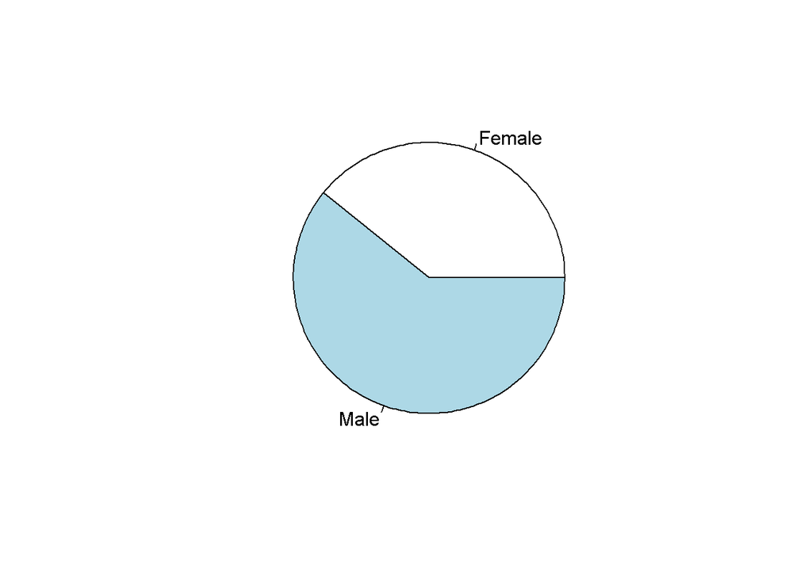

```r
gender_ratio_pie <- c(0.3921569,0.6078431)
pie(gender_ratio_pie, label=c("Female","Male"))
```

### Cinsiyetlerin, oyuncuların son güncellemeyi beğenmesine göre etkisi

```r
library(ggplot2)
projectr
```

```
## # A tibble: 153 x 7
##      AGE LANE    `LAST PATCH` ELO        GENDER MAP             `GAME MODES`
##    <dbl> <chr>          <dbl> <chr>      <chr>  <chr>           <chr>
##  1    27 Support            2 Silver     Male   Summoner's Rift Ultimate Spellb~
##  2    20 Mid                5 Silver     Female Summoner's Rift URF
##  3    19 Adc                4 Silver     Female Summoner's Rift URF
##  4    20 Adc                2 Silver     Female Summoner's Rift URF
##  5    18 Top                2 Silver     Female Summoner's Rift URF
##  6    27 Top                0 Gold       Female Aram            URF
##  7    26 Top                2 Challenger Female Summoner's Rift URF
##  8    29 Top                2 Challenger Male   Summoner's Rift URF
##  9    27 Jungle             5 Master     Male   Summoner's Rift URF
## 10    23 Jungle             0 Master     Male   Summoner's Rift URF
## # ... with 143 more rows
```

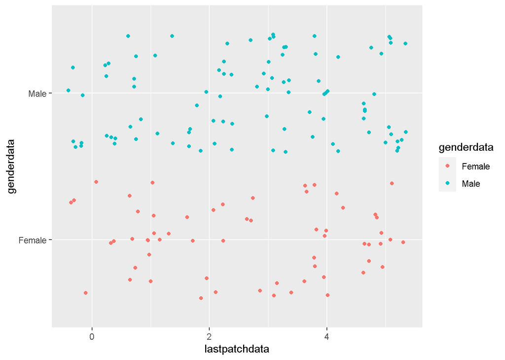

```r
genderdata <- projectr$GENDER
lastpatchdata <- projectr$`LAST PATCH`
ggplot(projectr, aes(x= lastpatchdata, y=genderdata, color=genderdata)) + geom_jitter()
```

### Cinsiyetlerin, oyuncuların kümelerine etkisi

```r
projectr
```

```
## # A tibble: 153 x 7
##      AGE LANE    `LAST PATCH` ELO        GENDER MAP             `GAME MODES`
##    <dbl> <chr>          <dbl> <chr>      <chr>  <chr>           <chr>
##  1    27 Support            2 Silver     Male   Summoner's Rift Ultimate Spellb~
##  2    20 Mid                5 Silver     Female Summoner's Rift URF
##  3    19 Adc                4 Silver     Female Summoner's Rift URF
##  4    20 Adc                2 Silver     Female Summoner's Rift URF
##  5    18 Top                2 Silver     Female Summoner's Rift URF
##  6    27 Top                0 Gold       Female Aram            URF
##  7    26 Top                2 Challenger Female Summoner's Rift URF
##  8    29 Top                2 Challenger Male   Summoner's Rift URF
##  9    27 Jungle             5 Master     Male   Summoner's Rift URF
## 10    23 Jungle             0 Master     Male   Summoner's Rift URF
## # ... with 143 more rows
```

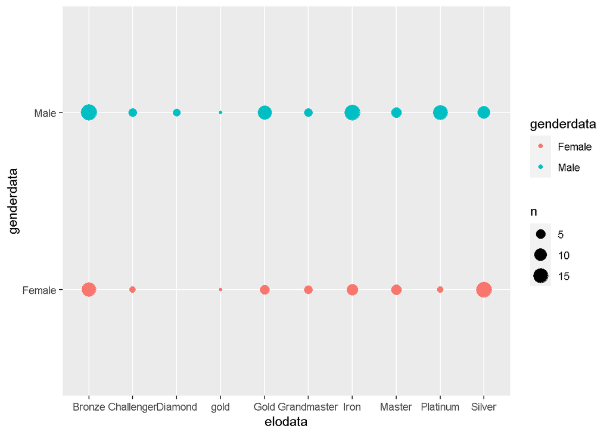

```r
genderdata <- projectr$GENDER
elodata <- projectr$ELO
ggplot(projectr, aes(x= elodata, y=genderdata, color=genderdata)) + geom_count()
```

### Challenger elo oyuncuların son güncelleme hakkındaki düşünceleri

Challeger elo oyuncular bu güncellemeyi 5 üzerinden ortalama 2,16 beğenmiştir. Yani güncellemede yapılan değişikliklerden büyük bir çoğunluğu memnun değil.

```r
challenger_last_patch <- projectr[projectr$ELO == "Challenger", "LAST PATCH"]
challenger_last_patch
```

```
## # A tibble: 6 x 1
##   `LAST PATCH`
##          <dbl>
## 1            2
## 2            2
## 3            2
## 4            4
## 5            1
## 6            2
```

```r
mean(challenger_last_patch)
```

```
## [1] NA
```

### Bronze oyunculardan bi data frame oluşturup inceyelim.

Oyundaki çoğunluğu oluşturan bronze elo oyuncuları bu yamayı 5 üzerinden 3 beğenmişler.

```r
bronze_data <- subset(projectr, ELO== "Bronze")
bronze_data
```

```
## # A tibble: 33 x 7
##      AGE LANE     `LAST PATCH` ELO    GENDER MAP             `GAME MODES`
##    <dbl> <chr>           <dbl> <chr>  <chr>  <chr>           <chr>
##  1    29 Support             5 Bronze Male   Summoner's Rift URF
##  2    18 Adc                 0 Bronze Male   Summoner's Rift URF
##  3    23 Mid                 5 Bronze Male   Summoner's Rift URF
##  4    23 Support             5 Bronze Male   Summoner's Rift URF
##  5    23 Support             3 Bronze Male   Summoner's Rift URF
##  6    21 Top Lane            0 Bronze Female Summoner's Rift URF
##  7    29 Adc                 3 Bronze Female Summoner's Rift URF
##  8    26 Support             4 Bronze Female Summoner's Rift URF
##  9    19 Top Lane            4 Bronze Female Summoner's Rift URF
## 10    19 Support             5 Bronze Female Summoner's Rift URF
## # ... with 23 more rows
```

```r
library(dplyr)
data <- data.frame()
bronze_data <- filter(projectr, ELO=="Bronze")
mean_last_patch <- mean(bronze_data$"LAST PATCH")
print(mean_last_patch)
```

```
## [1] 3
```

### Tüm kümelereki oyuncuların yeni güncelleme hakkındaki yorumları

Diğerlerine göre daha fazla silver, bronze ve demir oyuncunun ankete katıldığını görebiliyoruz. Ve katılım sağlayanlardan alınan en yüksek beğeni oranı elmas(diamond) elo oyunculardan alınmıştır(3,66). Son yamayı en az beğenen 5 üzerinen 2,16 ile challenger elo oyuncuları olmuştur.

```r
library(dplyr)

elo_levels <- unique(projectr$ELO)
elo_comments <- list()

for (level in elo_levels) {

  elo_data <- filter(projectr, ELO == level)


  comments <- paste(elo_data$`LAST PATCH`, collapse = ", ")


  elo_comments[[level]] <- comments
}


elo_comments
```

```
## $Silver
## [1] "2, 5, 4, 2, 2, 3, 2, 4, 3, 1, 2, 3, 5, 0, 1, 1, 0, 1, 3, 2, 5, 4, 1, 3, 2, 2, 5, 3"
##
## $Gold
## [1] "0, 3, 5, 5, 0, 4, 0, 4, 1, 1, 4, 5, 1, 3, 4, 5, 4, 0"
##
## $Challenger
## [1] "2, 2, 2, 4, 1, 2"
##
## $Master
## [1] "5, 0, 0, 1, 0, 3, 4, 1, 5, 4, 4, 2"
##
## $Grandmaster
## [1] "3, 4, 0, 2, 3, 5, 4, 0"
##
## $Platinum
## [1] "2, 4, 2, 3, 5, 0, 3, 1, 1, 2, 4, 0, 3, 0, 5, 1, 2"
##
## $Iron
## [1] "1, 2, 1, 1, 3, 5, 5, 5, 4, 3, 0, 1, 3, 3, 1, 5, 4, 2, 3, 0, 4, 5, 5, 5, 3, 3"
##
## $Bronze
## [1] "5, 0, 5, 5, 3, 0, 3, 4, 4, 5, 3, 0, 1, 2, 5, 5, 1, 3, 2, 1, 1, 2, 5, 5, 2, 4, 5, 4, 3, 2, 4, 5, 0"
##
## $Diamond
## [1] "1, 5, 5"
##
## $gold
## [1] "4, 1"
```

### Tüm oyuncuların genel memnuniyet durumu

Ankete katılan oyuncuların hepsinin son yamayı beğenme düzeyi 5 üzerinden 2,69 olmuştur.

```r
 # Verilen sayılar
numbers <- c(2.53, 2.65, 2.16, 2.41, 2.625, 2.23, 2.96, 3, 3.66)

# Ortalama hesaplama
mean(numbers)
```

```
## [1] 2.691667
```

### Hangi elo oyuncular hangi eğlence modunu seviyor

Genel kanı olaraktan tüm oyuncular Ultra rekabet faktörü (URF) modunu seviyor. URF modunu yeni gelecek yamada getirmek oyuncuların ilgisini çekecektir.

```r
library(ggplot2)
projectr
```

```
## # A tibble: 153 x 7
##      AGE LANE    `LAST PATCH` ELO        GENDER MAP             `GAME MODES`
##    <dbl> <chr>          <dbl> <chr>      <chr>  <chr>           <chr>
##  1    27 Support            2 Silver     Male   Summoner's Rift Ultimate Spellb~
##  2    20 Mid                5 Silver     Female Summoner's Rift URF
##  3    19 Adc                4 Silver     Female Summoner's Rift URF
##  4    20 Adc                2 Silver     Female Summoner's Rift URF
##  5    18 Top                2 Silver     Female Summoner's Rift URF
##  6    27 Top                0 Gold       Female Aram            URF
##  7    26 Top                2 Challenger Female Summoner's Rift URF
##  8    29 Top                2 Challenger Male   Summoner's Rift URF
##  9    27 Jungle             5 Master     Male   Summoner's Rift URF
## 10    23 Jungle             0 Master     Male   Summoner's Rift URF
## # ... with 143 more rows
```

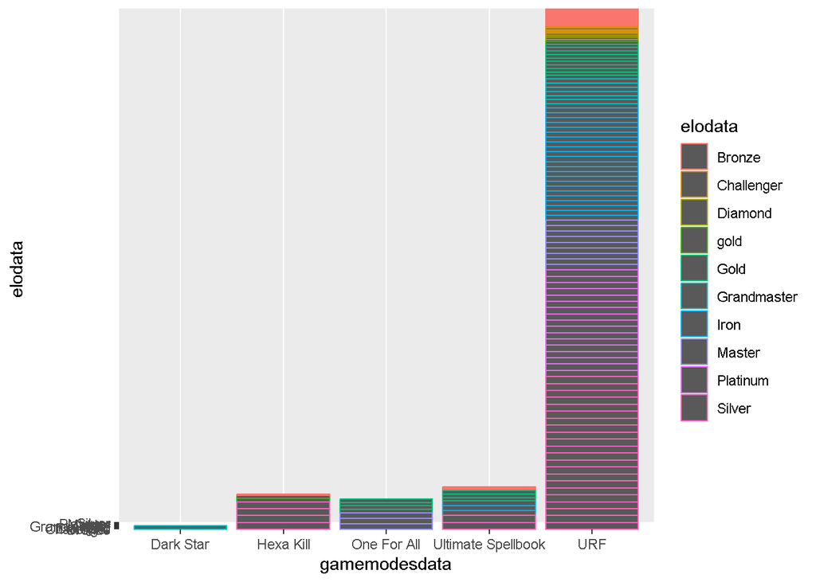

```r
elodata <- projectr$ELO
gamemodesdata <- projectr$`GAME MODES`
ggplot(projectr, aes(x= gamemodesdata, y=elodata, color=elodata)) + geom_col()
```

### Aktif olarak günde +4 saat League of Legends oynuyor mu?

Anket yapıldıktan sonra insanlara oyunu şuan aktif olarak günde +4 saat oynayıp oynamadıkları sorulmuş ama veri setine eklenmemiştir. 1 değeri kişinin günde 4 saat ya da daha fazla lol oynadığını,0 değeri ise 4 saatten daha az oynadıklarını göstermektedir.

```r
projectr <- mutate(projectr, z = c(1,0,0,1,1,1,1,1,0,1,1,0,0,1,1,1,1,1,0,1,1,0,0,1,1,1,1,1,0,1,1,0,0,1,1,1,1,1,0,1,1,0,0,1,1,1,1,1,0,1,1,0,0,1,1,1,1,1,0,1,1,0,0,1,1,1,1,1,0,1,1,0,0,1,1,1,1,1,0,1,1,0,0,1,1,1,1,1,0,1,1,0,0,1,1,1,1,1,0,1,1,0,0,1,1,1,1,1,0,1,1,0,0,1,1,1,1,1,0,1,1,0,0,1,1,1,1,1,0,1,1,0,0,1,1,1,1,1,0,1,1,0,0,1,1,1,1,1,0,1,0,1,0))
projectr
```

```
## # A tibble: 153 x 8
##      AGE LANE    `LAST PATCH` ELO        GENDER MAP           `GAME MODES`     z
##    <dbl> <chr>          <dbl> <chr>      <chr>  <chr>         <chr>        <dbl>
##  1    27 Support            2 Silver     Male   Summoner's R~ Ultimate Sp~     1
##  2    20 Mid                5 Silver     Female Summoner's R~ URF              0
##  3    19 Adc                4 Silver     Female Summoner's R~ URF              0
##  4    20 Adc                2 Silver     Female Summoner's R~ URF              1
##  5    18 Top                2 Silver     Female Summoner's R~ URF              1
##  6    27 Top                0 Gold       Female Aram          URF              1
##  7    26 Top                2 Challenger Female Summoner's R~ URF              1
##  8    29 Top                2 Challenger Male   Summoner's R~ URF              1
##  9    27 Jungle             5 Master     Male   Summoner's R~ URF              0
## 10    23 Jungle             0 Master     Male   Summoner's R~ URF              1
## # ... with 143 more rows
```

### Son yamayı beğenme durumu ile oyunu oynamaya devam etme arasındaki ilişki

Son yamayı beğenme durumu ile oyunu oynamaya devam etme arasındaki korelasyon katsayını -0,05 olduğu görülmüştür. Bu değer bize son yamayı beğenme durumunun insanların oyunu oynamaları durumuyla arasındaki ilişkinin çok zayıf olduğu hatta olmadığını göstermektedir. Yani bu verilere göre son güncellemeyi beğenen bir kişinin oyunu günde +4 saat oynayıp oynamayacağı hakkında bir bilgi elde edilememektedir.

```r
cor.test(projectr$z, projectr$'LAST PATCH')
```

```
##
##  Pearson's product-moment correlation
##
## data:  projectr$z and projectr$"LAST PATCH"
## t = -0.72989, df = 151, p-value = 0.4666
## alternative hypothesis: true correlation is not equal to 0
## 95 percent confidence interval:
##  -0.2159394  0.1003292
## sample estimates:
##         cor
## -0.05929289
```

### 25 yaşından büyüklerin yorumları

+25 yaş olan örneklemimizdeki büyük insanların son yama hakkında görüşlerini incelersek eğer ortalama 5 üzerinden 2,75 puanla son yamayı pek beğenmemiş olduklarını söyleyebiliriz.

```r
  library(readxl)
library(dplyr)

mean_25 <- projectr %>%
  filter(AGE > 25) %>%
  select('LAST PATCH')
summary(mean_25)
```

```
##    LAST PATCH
##  Min.   :0.00
##  1st Qu.:1.00
##  Median :3.00
##  Mean   :2.75
##  3rd Qu.:4.00
##  Max.   :5.00
```

### Kadınlar ve erkekler hangi oyun modlarından hoşlanıyor

```r
library(ggplot2)
install.packages("readxl")
library(readxl)
projectr <- read_excel("C:/Users/Baha/Desktop/projectr/projectr.xlsx")
projectr
```

```
## # A tibble: 153 x 7
##      AGE LANE    `LAST PATCH` ELO        GENDER MAP             `GAME MODES`
##    <dbl> <chr>          <dbl> <chr>      <chr>  <chr>           <chr>
##  1    27 Support            2 Silver     Male   Summoner's Rift Ultimate Spellb~
##  2    20 Mid                5 Silver     Female Summoner's Rift URF
##  3    19 Adc                4 Silver     Female Summoner's Rift URF
##  4    20 Adc                2 Silver     Female Summoner's Rift URF
##  5    18 Top                2 Silver     Female Summoner's Rift URF
##  6    27 Top                0 Gold       Female Aram            URF
##  7    26 Top                2 Challenger Female Summoner's Rift URF
##  8    29 Top                2 Challenger Male   Summoner's Rift URF
##  9    27 Jungle             5 Master     Male   Summoner's Rift URF
## 10    23 Jungle             0 Master     Male   Summoner's Rift URF
## # ... with 143 more rows
```

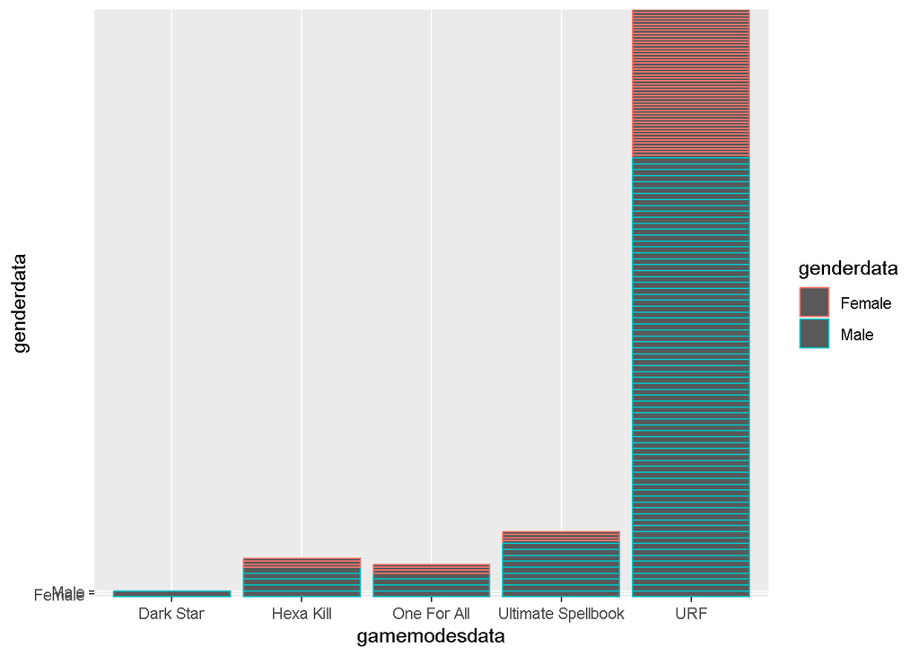

```r
genderdata <- projectr$GENDER
gamemodesdata <- projectr$`GAME MODES`
ggplot(projectr, aes(x= gamemodesdata, y=genderdata, color=genderdata)) + geom_col()
```

### Son yorumlar

Genel olarak League of Legends adlı oyunumuza gelen son yama pek beğeni görmemiştir. Ve özellikle incelenen +25 kitleninde oyundan memnun olmadığı saptanmıştır. Ve oyunculara sorulan en sevdiğiniz oyun modu nedir sorusunu açık ara Ultra rekabet faktörü (URF) modu kazanmış olup sıradaki güncellemede URF modunu oyuna eklemenin geri dönüşlerde iyi bir etki yaratacağı öngörülmektedir.